# Legal Analytics Problem Set 3 Part 3

## Andy Ninh, 2014

# Hierarchial Clustering

For the hierarchial clustering methods, the dendogram is the main graphical tool for getting insight into a cluster solution. To illustrate interpretation of the dendogram, we'll look at a cluster analysis performed on a set of cars from 1978-1979.

```r
library(foreign)
cars = read.delim("http://www.stat.berkeley.edu/classes/s133/data/cars.tab",
    stringsAsFactors = FALSE)
head(cars)
```

```
##   Country                       Car  MPG Weight Drive_Ratio Horsepower
## 1    U.S.        Buick Estate Wagon 16.9  4.360        2.73        155
## 2    U.S. Ford Country Squire Wagon 15.5  4.054        2.26        142
## 3    U.S.        Chevy Malibu Wagon 19.2  3.605        2.56        125
## 4    U.S.    Chrysler LeBaron Wagon 18.5  3.940        2.45        150
## 5    U.S.                  Chevette 30.0  2.155        3.70         68
## 6   Japan             Toyota Corona 27.5  2.560        3.05         95
##   Displacement Cylinders
## 1          350         8
## 2          351         8
## 3          267         8
## 4          360         8
## 5           98         4
## 6          134         4
```

It looks like the variables are measured on different scales, so we will likely want to standardize the data before proceeding.

```r
cars.use = cars[, -c(1, 2)]
medians = apply(cars.use, 2, median)
mads = apply(cars.use, 2, mad)
cars.use = scale(cars.use, center = medians, scale = mads)
cars.use
```

```
##           MPG   Weight Drive_Ratio Horsepower Displacement Cylinders
##  [1,] -0.8403  2.09217    -0.49182    1.57860      2.69128    4.7214
##  [2,] -1.0003  1.70996    -1.15226    1.20547      2.70464    4.7214
##  [3,] -0.5773  1.14913    -0.73070    0.71754      1.58272    4.7214
##  [4,] -0.6573  1.56757    -0.88527    1.43509      2.82485    4.7214
##  [5,]  0.6573 -0.66200     0.87122   -0.91846     -0.67449   -0.6745
##  [6,]  0.3715 -0.15613    -0.04216   -0.14351     -0.19367   -0.6745
##  [7,]  0.3372 -0.48089     0.64639   -0.08611     -0.39401   -0.6745
##  [8,]  0.7602 -0.56832     0.40750   -0.71754     -0.58100   -0.6745
##  [9,] -0.4516  0.18111     1.15226    0.08611     -0.23373    0.6745
## [10,] -0.8288  0.56832     0.59018    0.71754      0.19367    2.0235
## [11,] -0.3029  0.13740     0.96958    0.43053     -0.36730   -0.6745
## [12,] -0.9203  0.90557     0.70259    0.94716      0.19367    2.0235
## [13,] -0.4173  0.86809    -0.49182    0.14351      1.10189    2.0235
## [14,] -0.3944  0.48089     0.00000   -0.43053      0.68785    2.0235
```

[output cut: 34 more lines]

(The 2 used as the second argument to apply means to apply the function to the columns of the matrix or data frame; a value of 1 means to use the rows.) The country of origin and name of the car will not be useful in the cluster analysis, so they have been removed. Notice that the scale function doesn't change the order of the rows of the data frame, so it will be easy to identify observations using the omitted columns from the original data.

First, we'll take a look at a hierarchical method, since it will provide information about solutions with different numbers of clusters. The first step is calculating a distance matrix. For a data set with n observations, the distance matrix will have n rows and n columns; the (i,j)th element of the distance matrix will be the difference between observation i and observation j. There are two functions that can be used to calculate distance matrices in R; the dist function, which is included in every version of R, and the daisy function, which is part of the cluster library. We'll use the dist function in this example, but you should familiarize yourself with the daisy function (by reading its help page), since it offers some capabilities that dist does not. Each function provides a choice of distance metrics; in this example, we'll use the default of Euclidean distance, but you may find that using other metrics will give different insights into the structure of your data.

```r
cars.dist = dist(cars.use)
cars.dist
```

```
##          1       2       3       4       5       6       7       8       9
## 2  0.86445
## 3  1.72796 1.47239
## 4  0.70845 0.52569 1.50437
## 5  7.63975 7.58380 6.65268 7.52895
## 6  6.86514 6.77735 6.00759 6.74240 1.41548
## 7  7.12102 7.08589 6.24973 7.02299 0.97841 0.79004
## 8  7.45283 7.37105 6.47235 7.32068 0.53245 1.00136 0.82299
## 9  5.80235 5.84928 4.95725 5.80246 2.24559 2.02285 1.78647 2.27397
## 10 4.21325 4.26508 3.36954 4.23342 3.80927 3.24592 3.27627 3.71335 1.73474
## 11 6.78487 6.82750 6.08200 6.77690 1.86681 1.38722 1.07898 1.81880 1.41901
## 12 4.09352 4.21244 3.39005 4.17958 4.06052 3.45966 3.49268 3.96659 1.92108
## 13 3.67994 3.52993 2.82867 3.55211 4.11292 3.30353 3.64060 3.88730 2.60443
## 14 4.28558 4.15071 3.22673 4.16653 3.54181 3.02203 3.23206 3.40168 2.08729
## 15 3.55351 3.43132 2.79795 3.48448 4.31179 3.45804 3.80367 4.08762 2.69147
## 16 3.35036 3.22369 2.72878 3.23597 4.49879 3.60846 3.93211 4.27147 2.86812
## 17 1.22487 0.80086 0.68704 0.95776 7.06050 6.33618 6.61557 6.86531 5.33824
## 18 1.42813 0.89109 0.68216 1.05706 7.03951 6.30348 6.59858 6.83176 5.36719
## 19 0.96562 0.20382 1.36457 0.50694 7.49015 6.69994 7.00765 7.27780 5.78749
## 20 1.06175 0.69244 0.81383 0.72117 7.12252 6.38993 6.66533 6.92446 5.40636
## 21 6.85877 6.76284 5.99788 6.73805 1.36080 0.25022 0.83447 0.98663 1.98577
## 22 4.31123 4.22620 3.24295 4.19833 3.48141 2.87879 3.04063 3.30975 1.87242
## 23 7.93329 7.87777 6.90474 7.80387 0.55238 1.78008 1.37700 0.79872 2.65650
## 24 7.67122 7.54025 6.63107 7.47869 1.26517 1.35393 1.41604 0.85476 2.88556
## 25 7.01737 6.91999 6.11256 6.90490 1.21415 0.48609 0.93312 0.83334 2.07360
## 26 7.79786 7.75037 6.79379 7.68065 0.32616 1.61369 1.10578 0.69666 2.39722
## 27 7.52864 7.38815 6.48995 7.36721 0.91550 1.07973 1.16498 0.53944 2.51188
## 28 6.77674 6.61712 5.91586 6.60937 2.01247 0.79720 1.57152 1.52964 2.57561
## 29 4.57164 4.41923 3.43030 4.34152 3.52666 2.85653 3.10837 3.25583 2.48484
## 30 4.44857 4.32723 3.33543 4.25744 3.48709 2.82912 3.04719 3.24668 2.24727
## 31 6.95290 6.82492 6.07851 6.77618 1.82347 0.89363 1.50686 1.31530 2.70473
## 32 7.60099 7.51982 6.60344 7.45682 0.67880 1.28684 1.16128 0.40537 2.55664
## 33 7.84972 7.78741 6.82283 7.72703 0.32915 1.64334 1.22441 0.66944 2.49354
## 34 7.78736 7.67754 6.74365 7.61538 1.19073 1.56054 1.59570 0.87148 2.97702
## 35 7.55252 7.51365 6.59166 7.44787 0.29620 1.28365 0.77167 0.48831 2.14909
## 36 4.83694 4.84620 3.76549 4.79400 3.14624 2.93922 2.86824 3.12438 1.41656
## 37 6.84715 6.85022 6.08703 6.80728 1.67566 1.17296 0.85130 1.60223 1.45354
## 38 7.83892 7.78863 6.82792 7.71573 0.40523 1.66436 1.15726 0.74093 2.45821
##         10      11      12      13      14      15      16      17      18
## 2
```

[output cut: 135 more lines]

```
## 24
## 25
## 26
## 27
## 28
## 29
## 30
## 31
## 32
## 33
## 34
## 35
## 36
## 37
## 38 1.89704
```

When we display the distance matrix in R (for example, by typing its name), you'll notice that only the lower triangle of the matrix is displayed. This is to remind us that the distance matrix is symmetric, since it doesn't matter which observation we consider first when we calculate a distance. R takes advantage of this fact by only storing the lower triangle of the distance matrix. All of the clustering functions will recognize this and have no problems, but if you try to access the distance matrix in the usual way (for example, with subscripting), you'll see an error message. Thus, if you need to use the distance matrix with anything other than the clustering functions, you'll need to use as.matrix to convert it to a regular matrix.

To get started, we'll use the hclust method; the cluster library provides a similar function, called agnes to perform hierarchical cluster analysis.

```r
cars.hclust = hclust(cars.dist)
cars.hclust
```

```
##
## Call:
## hclust(d = cars.dist)
##
## Cluster method   : complete
## Distance         : euclidean
## Number of objects: 38
```

Once again, we're using the default method of hclust, which is to update the distance matrix using what R calls “complete” linkage. Using this method, when a cluster is formed, its distance to other objects is computed as the maximum distance between any object in the cluster and the other object. Other linkage methods will provide different solutions, and should not be ignored. For example, using method=ward tends to produce clusters of fairly equal size, and can be useful when other methods find clusters that contain just a few observations.

Now that we've got a cluster solution (actually a collection of cluster solutions), how can we examine the results? The main graphical tool for looking at a hierarchical cluster solution is known as a dendogram. This is a tree-like display that lists the objects which are clustered along the x-axis, and the distance at which the cluster was formed along the y-axis. (Distances along the x-axis are meaningless in a dendogram; the observations are equally spaced to make the dendogram easier to read.) To create a dendogram from a cluster solution, simply pass it to the plot function. The result is displayed below.

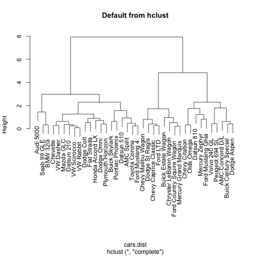

```r
plot(cars.hclust, labels = cars$Car, main = "Default from hclust")
```

If you choose any height along the y-axis of the dendogram, and move across the dendogram counting the number of lines that you cross, each line represents a group that was identified when objects were joined together into clusters. The observations in that group are represented by the branches of the dendogram that spread out below the line. For example, if we look at a height of 6, and move across the x-axis at that height, we'll cross two lines. That defines a two-cluster solution; by following the line down through all its branches, we can see the names of the cars that are included in these two clusters. Since the y-axis represents how close together observations were when they were merged into clusters, clusters whose branches are very close together (in terms of the heights at which they were merged) probably aren't very reliable. But if there's a big difference along the y-axis between the last merged cluster and the currently merged one, that indicates that the clusters formed are probably doing a good job in showing us the structure of the data. Looking at the dendogram for the car data, there are clearly two very distinct groups; the right hand group seems to consist of two more distinct cluster, while most of the observations in the left hand group are clustering together at about the same height For this data set, it looks like either two or three groups might be an interesting place to start investigating. This is not to imply that looking at solutions with more clusters would be meaningless, but the data seems to suggest that two or three clusters might be a good start. For a problem of this size, we can see the names of the cars, so we could start interpreting the results immediately from the dendogram, but when there are larger numbers of observations, this won't be possible.

One of the first things we can look at is how many cars are in each of the groups. We'd like to do this for both the two cluster and three cluster solutions. You can create a vector showing the cluster membership of each observation by using the cutree function. Since the object returned by a hierarchical cluster analysis contains information about solutions with different numbers of clusters, we pass the cutree function the cluster object and the number of clusters we're interested in. So to get cluster memberships for the three cluster solution, we could use:

```r
groups.3 = cutree(cars.hclust, 3)
```

Simply displaying the group memberships isn't that revealing. A good first step is to use the table function to see how many observations are in each cluster. We'd like a solution where there aren't too many clusters with just a few observations, because it may make it difficult to interpret our results. For the three cluster solution, the distribution among the clusters looks good:

```r
table(groups.3)
```

```
## groups.3
##  1  2  3
##  8 20 10
```

Notice that you can get this information for many different groupings at once by combining the calls to *cutree* and *table* in a call to *sapply*. For example, to see the sizes of the clusters for solutions ranging from 2 to 6 clusters, we could use:

```r
counts = sapply(2:6, function(ncl) table(cutree(cars.hclust, ncl)))
names(counts) = 2:6
counts
```

```
## $`2`
##
##  1  2
## 18 20
##
## $`3`
##
##  1  2  3
##  8 20 10
##
## $`4`
##
##  1  2  3  4
##  8 17  3 10
##
## $`5`
##
##  1  2  3  4  5
##  8 11  6  3 10
##
## $`6`
##
##  1  2  3  4  5  6
##  8 11  6  3  5  5
```

```r
cars$Car[groups.3 == 1]
```

```
## [1] "Buick Estate Wagon"        "Ford Country Squire Wagon"
## [3] "Chevy Malibu Wagon"        "Chrysler LeBaron Wagon"
## [5] "Chevy Caprice Classic"     "Ford LTD"
## [7] "Mercury Grand Marquis"     "Dodge St Regis"
```

As usual, if we want to do the same thing for all the groups at once, we can use *sapply*:

```r
sapply(unique(groups.3), function(g) cars$Car[groups.3 == g])
```

```
## [[1]]
## [1] "Buick Estate Wagon"        "Ford Country Squire Wagon"
## [3] "Chevy Malibu Wagon"        "Chrysler LeBaron Wagon"
## [5] "Chevy Caprice Classic"     "Ford LTD"
## [7] "Mercury Grand Marquis"     "Dodge St Regis"
##
## [[2]]
##  [1] "Chevette"         "Toyota Corona"    "Datsun 510"
##  [4] "Dodge Omni"       "Audi 5000"        "Saab 99 GLE"
##  [7] "Ford Mustang 4"   "Mazda GLC"        "Dodge Colt"
## [10] "AMC Spirit"       "VW Scirocco"      "Honda Accord LX"
## [13] "Buick Skylark"    "Pontiac Phoenix"  "Plymouth Horizon"
## [16] "Datsun 210"       "Fiat Strada"      "VW Dasher"
## [19] "BMW 320i"         "VW Rabbit"
##
## [[3]]
##  [1] "Volvo 240 GL"          "Peugeot 694 SL"
##  [3] "Buick Century Special" "Mercury Zephyr"
##  [5] "Dodge Aspen"           "AMC Concord D/L"
##  [7] "Ford Mustang Ghia"     "Chevy Citation"
##  [9] "Olds Omega"            "Datsun 810"
```

We could also see what happens when we use the four cluster solution.

```r
groups.4 = cutree(cars.hclust, 4)
sapply(unique(groups.4), function(g) cars$Car[groups.4 == g])
```

```
## [[1]]
## [1] "Buick Estate Wagon"        "Ford Country Squire Wagon"
## [3] "Chevy Malibu Wagon"        "Chrysler LeBaron Wagon"
## [5] "Chevy Caprice Classic"     "Ford LTD"
## [7] "Mercury Grand Marquis"     "Dodge St Regis"
##
## [[2]]
##  [1] "Chevette"         "Toyota Corona"    "Datsun 510"
##  [4] "Dodge Omni"       "Ford Mustang 4"   "Mazda GLC"
##  [7] "Dodge Colt"       "AMC Spirit"       "VW Scirocco"
## [10] "Honda Accord LX"  "Buick Skylark"    "Pontiac Phoenix"
## [13] "Plymouth Horizon" "Datsun 210"       "Fiat Strada"
## [16] "VW Dasher"        "VW Rabbit"
##
## [[3]]
## [1] "Audi 5000"   "Saab 99 GLE" "BMW 320i"
##
## [[4]]
##  [1] "Volvo 240 GL"          "Peugeot 694 SL"
##  [3] "Buick Century Special" "Mercury Zephyr"
##  [5] "Dodge Aspen"           "AMC Concord D/L"
##  [7] "Ford Mustang Ghia"     "Chevy Citation"
##  [9] "Olds Omega"            "Datsun 810"
```

The new cluster can be recognized as the third group in the above output.

Often there is an auxiliary variable in the original data set that was not included in the cluster analysis, but may be of interest. In fact, cluster analysis is sometimes performed to see if observations naturally group themselves in accord with some already measured variable. For this data set, we could ask whether the clusters reflect the country of origin of the cars, stored in the variable *Country* in the original data set. The *table* function can be used, this time passing two arguments, to produce a cross-tabulation of cluster group membership and country of origin:

```r
table(groups.3, cars$Country)
```

```
##
## groups.3 France Germany Italy Japan Sweden U.S.
##        1      0       0     0     0      0    8
##        2      0       5     1     6      1    7
##        3      1       0     0     1      1    7
```

Of interest is the fact that all of the cars in cluster 1 were manufactured in the US. Considering the state of the automobile industry in 1978, and the cars that were identified in cluster 1, this is not surprising.

In an example like this, with a small number of observations, we can often interpret the cluster solution directly by looking at the labels of the observations that are in each cluster. Of course, for larger data sets, this will be impossible or meaningless. A very useful method for characterizing clusters is to look at some sort of summary statistic, like the median, of the variables that were used to perform the cluster analysis, broken down by the groups that the cluster analysis identified. The *aggregate* function is well suited for this task, since it will perform summaries on many variables simultaneously. Let's look at the median values for the variables we've used in the cluster analysis, broken up by the cluster groups. One oddity of the *aggregate* function is that it demands that the variable(s) used to divide up the data are passed to it in a list, even if there's only one variable:

```r
aggregate(cars.use, list(groups.3), median)
```

```
##   Group.1     MPG  Weight Drive_Ratio Horsepower Displacement Cylinders
## 1       1 -0.7945  1.5051     -0.9134     1.0476       2.4776    4.7214
## 2       2  0.6859 -0.5871      0.5269    -0.6027      -0.5810   -0.6745
## 3       3 -0.4058  0.5246     -0.1686     0.3588       0.3272    2.0235
```

```r
aggregate(cars[, -c(1, 2)], list(groups.3), median)
```

```
##   Group.1   MPG Weight Drive_Ratio Horsepower Displacement Cylinders
## 1       1 17.30  3.890       2.430      136.5          334         8
## 2       2 30.25  2.215       3.455       79.0          105         4
## 3       3 20.70  3.105       2.960      112.5          173         6
```

It may also be useful to add the numbers of observations in each group to the above display. Since *aggregate* returns a data frame, we can manipulate it in any way we want:

```r
a3 = aggregate(cars[, -c(1, 2)], list(groups.3), median)
data.frame(Cluster = a3[, 1], Freq = as.vector(table(groups.3)), a3[, -1])
```

```
##   Cluster Freq   MPG Weight Drive_Ratio Horsepower Displacement Cylinders
## 1       1    8 17.30  3.890       2.430      136.5          334         8
## 2       2   20 30.25  2.215       3.455       79.0          105         4
## 3       3   10 20.70  3.105       2.960      112.5          173         6
```

To see how the four cluster solution differed from the three cluster solution, we can perform the same analysis for that solution:

```r
a4 = aggregate(cars[, -c(1, 2)], list(groups.4), median)
data.frame(Cluster = a4[, 1], Freq = as.vector(table(groups.4)), a4[, -1])
```

```
##   Cluster Freq  MPG Weight Drive_Ratio Horsepower Displacement Cylinders
## 1       1    8 17.3  3.890        2.43      136.5          334         8
## 2       2   17 30.9  2.190        3.37       75.0           98         4
## 3       3    3 21.5  2.795        3.77      110.0          121         4
## 4       4   10 20.7  3.105        2.96      112.5          173         6
```

The main difference seems to be that the four cluster solution recognized a group of cars that have higher horsepower and drive ratios than the other cars in the cluster they came from.